# The Collection and Analysis of Zooplankton

Claire Estey

2024-12-05

### Notes (not to be included)

put this in a folder titled final or something and have it render as an html_ file_document, leave README as .Rmd

try to change date to system date in yaml header can also change html style (tufte?) due? integrate equations bibliography needs to be reproducible - just share with Dr. Paez (not a collaborator)

practice ref: (Arnold et al. 2023)

### Install Packages

- tidyverse
- here

### *Introduction*

Benzalkonium chloride (BAC) is a potent antimicrobial currently listed as the number one active ingredient in disinfectants approved by the Government of Canada for use against COVID-19 (Marteinson et al. 2022). Consequently, BAC use has increased in industrial, clinical, and household settings since the onset of the pandemic (Marteinson et al. 2022; Mohapatra et al. 2023). Such widespread use has led to the continuous discharge of these compounds into aquatic environments primarily via wastewater treatment plant effluent, with surface water concentrations being found to range from less than 1 to ~100 µg/L globally (Mohapatra et al. 2023). Though the half-life of BAC in its aqueous form is estimated to be 5 to 7 days, its continuous input into freshwater systems creates pseudo-persistence and ongoing exposure of downstream aquatic biota (Marteinson et al. 2022; DeLeo et al. 2020).

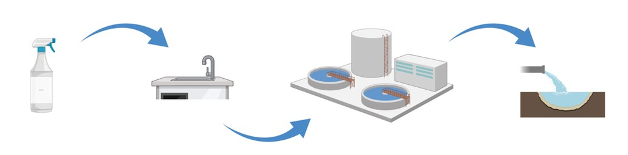

Little is known about the effects of chronic BAC exposure in aquatic environments, particularly on lower-trophic-level organisms such as biofilm, phytoplankton, and zooplankton (Marteinson et al. 2022). While some laboratory studies have investigated the acute toxicity of BAC on aquatic species – finding algae to be particularly sensitive (Hora et al. 2020; Jing, Zhou, and Zhuo 2012) – these studies fail to capture the complexity of natural ecosystems and lack the ability to assess the indirect effects of a contaminant.

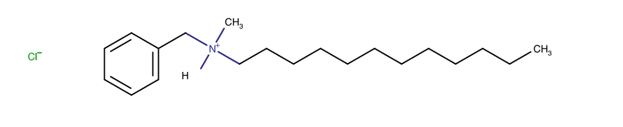

BAC is a cationic surfactant containing a positively charged ammonium headgroup bonded to an alkyl chain of varying lengths ranging from 8 to 18 carbons (Arnold et al. 2023). It’s efficacy in breaking down bacterial cell walls is due to the electrostatic interactions between the positively charged quaternary nitrogen headgroup and negatively charged phospholipids and structural bacterial proteins of the cell membrane (Maillard 2002; Gilbert and Moore 2005; Jennings, Minbiole, and Wuest 2015). A similar mode of action is seen against the protective lipid layer of viruses (Mohapatra et al. 2023). Generally, antimicrobial activity increases with increasing alkyl chain length, with BAC C12 to C16 being the most effective (Gerba 2015) The same properties that make BAC effective against bacteria and viruses also make it potentially toxic to aquatic biota, particularly lower-trophic-level organisms.

Considering the increased use and environmental release of antimicrobial products since the onset of COVID-19, it is essential to study their effects on aquatic organisms (Marteinson et al. 2022). The abundance and diversity of lower-trophic-level organisms are integral to the structure and function of aquatic ecosystems. Biofilms and phytoplankton are important in dictating water quality, as they ensure the decomposition of organic matter and act as primary producers (Sentenac et al. 2022). Meanwhile, zooplankton facilitate energy transfer up the food web and have impacts on lake biogeochemical processes and productivity (Pinel-Alloul, Patoine, and Marty 2021). Zooplankton are known for their sensitivity to environmental change, including contaminants, and are useful indicators for detecting these disturbances (Pinel-Alloul, Patoine, and Marty 2021; Yan et al. 1996). Understanding the effects of BAC on aquatic biota, particularly lower-trophic-level organisms, is necessary to assess potential bottom-up effects this compound may have on aquatic ecosystems in Canada.

### *Objective*

The objective of my research is to investigate the effects of chronic BAC exposure on biofilm, phytoplankton, and zooplankton communities in a northern Ontario lake. I predict that with increasing BAC concentration, biofilm and phytoplankton chlorophyll a will decrease, thus reducing the abundance and diversity of the zooplankton communities that rely on these food sources.

### *Methodology*

Beginning in June of 2023, an eleven-week mesocosm study was conducted at the International Institute for Sustainable Development – Experimental Lakes Area (IISD-ELA) to assess the effects of chronic BAC exposure on aquatic ecosystems using five environmentally relevant concentrations (nominal 20, 112, 632, 3556, and 20 000 ng/L; with three controls of 0 ng/L). Eight mesocosms – enclosures made of a floating, 2 m diameter ring with an impermeable polyethylene curtain sandbagged to the bottom of the lake – were deployed in the north basin of Lake 375. Enclosures were spiked weekly with a technical mixture of BAC homologs with varying alkyl chain lengths (C10 to C18) to mimic BAC’s pseudo-persistent behaviour and to ensure target concentrations were maintained.

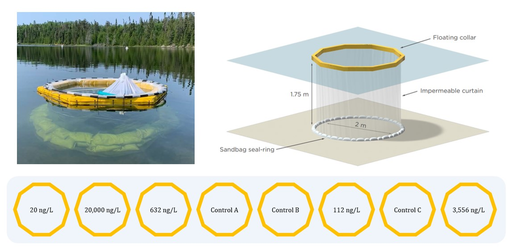

Colonization strips were installed in the photic zone of each enclosure and sampled for biofilm chlorophyll a and ash-free dry mass. Water samples from each enclosure were taken every 21 days to determine phytoplankton chlorophyll a and community assemblage (Havens, Cooney, and Stainton 2024). Zooplankton samples were collected using a Schindler-Patalas plankton trap lowered to 0.5 m and preserved in a 5% sugar-formalin solution at two- to three-week intervals (Prepas 1978). In the laboratory, zooplankton samples were identified to species and life stage for abundance and diversity analyses. Multivariate analyses will be used to discern the drivers of shifts in community composition.

### References

Arnold, William A, Arlene Blum, Jennifer Branyan, Thomas A Bruton, Courtney C Carignan, Gino Cortopassi, Sandipan Datta, et al. 2023. “Quaternary Ammonium Compounds: A Chemical Class of Emerging Concern.” *Environmental Science & Technology* 57 (20): 7645–65.

DeLeo, Paul C, Carolyn Huynh, Mala Pattanayek, Katherine Clark Schmid, and Nathan Pechacek. 2020. “Assessment of Ecological Hazards and Environmental Fate of Disinfectant Quaternary Ammonium Compounds.” *Ecotoxicology and Environmental Safety* 206: 111116.

Gerba, Charles P. 2015. “Quaternary Ammonium Biocides: Efficacy in Application.” *Applied and Environmental Microbiology* 81 (2): 464–69.

Gilbert, Peter, and LE Moore. 2005. “Cationic Antiseptics: Diversity of Action Under a Common Epithet.” *Journal of Applied Microbiology* 99 (4): 703–15.

Havens, Sonya, Blake Cooney, and Michael Stainton. 2024. *The Chemical Analysis of Fresh Water, Third Edition*. International Institute for Sustainable Development - Experimental Lakes Area.

Hora, Priya I, Sarah G Pati, Patrick J McNamara, and William A Arnold. 2020. “Increased Use of Quaternary Ammonium Compounds During the SARS-CoV-2 Pandemic and Beyond: Consideration of Environmental Implications.” *Environmental Science & Technology Letters* 7 (9): 622–31.

Jennings, MC, KPC Minbiole, and WM Wuest. 2015. “Quaternary Ammonium Compounds: An Antimicrobial Mainstay and Platform for Innovation to Address Bacterial Resistance.” *ACS Infectious Diseases*. ACS Publications.

Jing, Guohua, Zuoming Zhou, and Jing Zhuo. 2012. “Quantitative Structure–Activity Relationship (QSAR) Study of Toxicity of Quaternary Ammonium Compounds on Chlorella Pyrenoidosa and Scenedesmus Quadricauda.” *Chemosphere* 86 (1): 76–82.

Maillard, J-Y. 2002. “Bacterial Target Sites for Biocide Action.” *Journal of Applied Microbiology* 92 (s1): 16S–27S.

Marteinson, Sarah C, Michael J Lawrence, Zofia E Taranu, Kerri Kosziwka, Jessica J Taylor, Alexandria Green, Amanda K Winegardner, et al. 2022. “Increased Use of Sanitizers and Disinfectants During the COVID-19 Pandemic: Identification of Antimicrobial Chemicals and Considerations for Aquatic Environmental Contamination.” *Environmental Reviews* 31 (1): 76–94.

Mohapatra, Sanjeeb, Lin Yutao, Shin Giek Goh, Charmaine Ng, You Luhua, Ngoc Han Tran, and Karina Yew-Hoong Gin. 2023. “Quaternary Ammonium Compounds of Emerging Concern: Classification, Occurrence, Fate, Toxicity and Antimicrobial Resistance.” *Journal of Hazardous Materials* 445: 130393.

Pinel-Alloul, Bernadette, Alain Patoine, and Jérôme Marty. 2021. “Multi-Scale and Multi-System Perspectives of Zooplankton Structure and Function in Canadian Freshwaters.” *Canadian Journal of Fisheries and Aquatic Sciences* 78 (10): 1543–62.

Prepas, Ellie. 1978. “Sugar-Frosted Daphnia: An Improved Fixation Technique for Cladocera.”

Sentenac, Hugo, Adeline Loyau, Joséphine Leflaive, and Dirk S Schmeller. 2022. “The Significance of Biofilms to Human, Animal, Plant and Ecosystem Health.” *Functional Ecology* 36 (2): 294–313.

Yan, Norman D, Wendel Keller, Keith M Somers, Trevor W Pawson, and Robert E Girard. 1996. “Recovery of Crustacean Zooplankton Communities from Acid and Metal Contamination: Comparing Manipulated and Reference Lakes.” *Canadian Journal of Fisheries and Aquatic Sciences* 53 (6): 1301–27.